# 140.653 Lab 6

Erjia Cui & Elizabeth Colantuoni

```r
library(ggplot2)
library(MASS)
library(tidyverse)
library(matrixcalc)
library(nlme)
```

For this lab, we will simulate longitudinal dataset with specific correlation structure. Then we will fit the dataset using both Generalized Least Squares (GLS) and Ordinary Least Squares (OLS) with the goal of understanding the impact of ignoring correlation in the data on the estimated regression coefficients and inferences we would make from the analysis.

## Load and Organize the Real Data

We select the first 60 children from Nepal Children Dataset and create the spline term. Then we specify the true coefficients to simulate linear predictors of each visit of each child.

```r
## load data
load("../nepal.anthro.rdata")
nepal <- nepal.anthro[nepal.anthro$id %in% unique(nepal.anthro$id)[1:60],]
nepal <- nepal[order(nepal$id,nepal$fuvisit),]
nepal <- nepal %>% dplyr::select(id, age, num, fuvisit)
rm(nepal.anthro)

## create the spline term
nepal$age_sp6 <- ifelse(nepal$age > 6, nepal$age - 6, 0)

## specify the true coefficient of each term
b0 = 5
b1 = 0.5
b2 = -0.35

## simulate linear predictors
eta <- b0 + b1*nepal$age + b2*nepal$age_sp6
```

## Simulate Residuals with Specified Correlation Structure

In the previous lab we introduced typical working correlation structures. We next simulate residuals with specified exchangable correlation structure. As an exercise, you could try to simulate data with other specified correlation structures such as AR(1). After simulating the residuals, we combine it with the simulated linear predictors to obtain the simulated outcomes.

```r
I <- length(unique(nepal$id)) ## number of subjects
n <- nrow(nepal) ## total number of visits
J <- n / I ## number of visits per subject

set.seed(22)
## Exchangable structure
sigma_exch <- matrix(0.8, nrow = J, ncol = J)
diag(sigma_exch) <- 1
is.positive.definite(sigma_exch)
```

```
## [1] TRUE
```

```r
Sigma_exch <- kronecker(diag(I), sigma_exch)

res_exch <- mvrnorm(1, mu = rep(0, n), Sigma = Sigma_exch)
Y_exch <- eta + res_exch
nepal$Y_exch <- Y_exch

# ## Unstructured structure
# sigma <- matrix(rnorm(J*J, 0.2, 0.2), nrow = J, ncol = J)
# sigma_unst <- t(sigma) %*% sigma
# diag(sigma_unst) <- 1
# is.positive.definite(sigma_unst) ## check if specified covariance matrix is positive definite
# Sigma_unst <- kronecker(diag(I), sigma_unst)
#
# res_unst <- mvrnorm(1, mu = rep(0, n), Sigma = Sigma_unst)
# Y_unst <- eta + res_unst
# nepal$Y_unst <- Y_unst

str(nepal)
```

```
## 'data.frame':    300 obs. of  6 variables:
##  $ id     : int  120011 120011 120011 120011 120011 120012 120012 120012 120012 120012 ...
##  $ age    : int  41 45 49 53 57 57 61 65 69 73 ...
##  $ num    : int  1 2 3 4 5 1 2 3 4 5 ...
##  $ fuvisit: int  0 1 2 3 4 0 1 2 3 4 ...
##  $ age_sp6: num  35 39 43 47 51 51 55 59 63 67 ...
##  $ Y_exch : num  13.1 13.7 15 15.5 15.8 ...
```

## Exploratory Plots

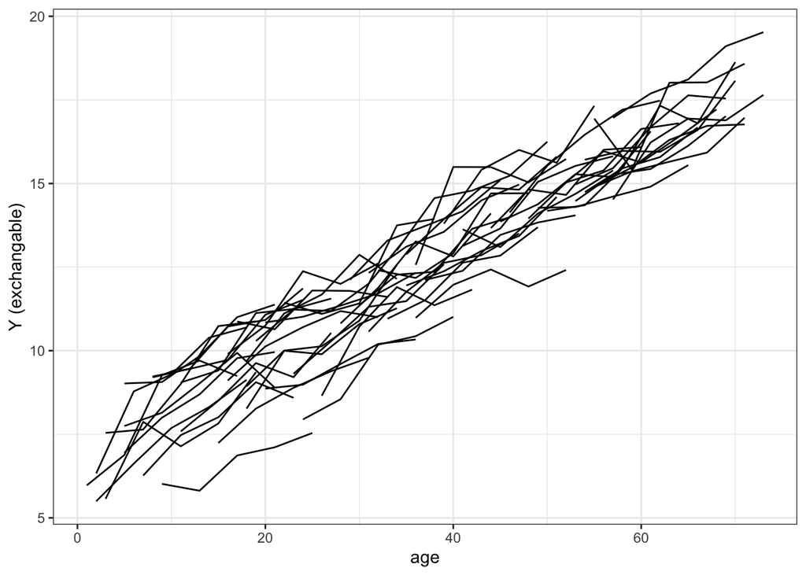

```r
## spaghetti plots
ggplot(data = nepal, aes(x = age, y = Y_exch, group = factor(id))) +
  theme_bw() +
  geom_line() +
  labs(y = "Y (exchangable)")
```

## Fit the Model Using GLS and OLS

After simulating the longitudinal dataset, we next fit both generalized least squares (GLS) which accounts for the correlation structure, and OLS which simply ignores the correlations within subject and assumes independence.

When fitting a GLS, `corCompSymm` gives the exchangeable correlation structure; `corSymm` gives unstructured correlation structure.

### 1. Results from One Simulation

We use `Y_exch`, the simulated outcome from exchangable correlation structures to fit the models. For GLS we use both exchangable and unstructured structure to fit the model. In this case, both correlation structure are theoretically correct.

```r
## GLS with exchangable structure
fit_exchdat_exchmod <- gls(Y_exch ~ age + age_sp6, data = nepal, correlation=corCompSymm(form=~1|id))
summary(fit_exchdat_exchmod)
```

```
## Generalized least squares fit by REML
##   Model: Y_exch ~ age + age_sp6
##   Data: nepal
##        AIC      BIC    logLik
##   589.4934 607.9621 -289.7467
##
## Correlation Structure: Compound symmetry
##  Formula: ~1 | id
##  Parameter estimate(s):
##      Rho
## 0.800937
##
## Coefficients:
##                 Value Std.Error   t-value p-value
## (Intercept)  5.012242 0.3722913 13.463229       0
## age          0.441918 0.0590648  7.481911       0
## age_sp6     -0.284857 0.0598327 -4.760886       0
##
##  Correlation:
##         (Intr) age
## age     -0.887
## age_sp6  0.863 -0.998
##
## Standardized residuals:
##         Min          Q1         Med          Q3         Max
## -3.02375438 -0.59871780 -0.05117528  0.83654053  2.41991104
##
## Residual standard error: 1.028624
## Degrees of freedom: 300 total; 297 residual
```

```r
## GLS with unstructured structure
fit_exchdat_unstmod <- gls(Y_exch ~ age + age_sp6, data = nepal, correlation=corSymm(form=~1|id))
summary(fit_exchdat_unstmod)
```

```
## Generalized least squares fit by REML
##   Model: Y_exch ~ age + age_sp6
##   Data: nepal
##        AIC     BIC    logLik
##   595.3617 647.074 -283.6809
##
## Correlation Structure: General
##  Formula: ~1 | id
##  Parameter estimate(s):
##  Correlation:
##   1     2     3     4
## 2 0.711
## 3 0.722 0.807
## 4 0.831 0.778 0.815
## 5 0.784 0.818 0.799 0.840
##
## Coefficients:
##                 Value Std.Error   t-value p-value
## (Intercept)  4.811590 0.3784379 12.714345       0
## age          0.480730 0.0621540  7.734495       0
## age_sp6     -0.324582 0.0630125 -5.151074       0
##
##  Correlation:
##         (Intr) age
## age     -0.909
## age_sp6  0.891 -0.998
##
## Standardized residuals:
##        Min         Q1        Med         Q3        Max
## -3.0903477 -0.6263686 -0.0480033  0.8429054  2.4602857
##
## Residual standard error: 1.01127
## Degrees of freedom: 300 total; 297 residual
```

```r
## OLS
fit_exchdat_ols <- lm(Y_exch ~ age + age_sp6, data = nepal)
summary(fit_exchdat_ols)
```

```
##
## Call:
## lm(formula = Y_exch ~ age + age_sp6, data = nepal)
##
## Residuals:
##      Min       1Q   Median       3Q      Max
## -3.09937 -0.61777 -0.04466  0.86574  2.49386
##
## Coefficients:
##             Estimate Std. Error t value Pr(>|t|)
## (Intercept)   5.4621     0.6964   7.843 7.96e-14 ***
## age           0.3638     0.1204   3.022  0.00273 **
## age_sp6      -0.2063     0.1213  -1.701  0.08998 .
## ---
## Signif. codes:  0 '***' 0.001 '**' 0.01 '*' 0.05 '.' 0.1 ' ' 1
##
## Residual standard error: 1.023 on 297 degrees of freedom
## Multiple R-squared:  0.892,  Adjusted R-squared:  0.8913
## F-statistic:  1226 on 2 and 297 DF,  p-value: < 2.2e-16
```

Comparing the variance estimates from different models, OLS has larger estimated standard error of coefficients then both GLS models. These should not be surprised since OLS overestimates the variance by ignoring the correlations between visits within each subject. We next compare their AIC.

```r
AIC(fit_exchdat_exchmod)
```

```
## [1] 589.4934
```

```r
AIC(fit_exchdat_unstmod)
```

```
## [1] 595.3617
```

```r
AIC(fit_exchdat_ols)
```

```
## [1] 869.9024
```

Even if both exchangable and unstructured models are correct, we still observe a slightly smaller AIC from exchangable model. This is very common in practice since specifying an unstructured correlation will increase the number of estimated parameters and add the complexity of the model. Although it is the most general correlation structure, it does not necessarily always give the best performance. If the correlation satisfies a simple structure well, a simple model will sometimes have better performance.

### 2. Results from Multiple Simulations

We next run the simulation 500 times, simulating exchangable longitudinal dataset one at a time. For each simulation, we extract the estimated coefficients from both GLS (exchangable) and OLS and plot their distributions.

```r
nsim <- 500

## create variables to store simulation results
coef_exchmod <- coef_ols <- matrix(NA, nrow = nsim, ncol = 3)

for(i in 1:nsim){
  res_exch <- mvrnorm(1, mu = rep(0, n), Sigma = Sigma_exch)
  Y_exch <- eta + res_exch
  nepal$Y_exch <- Y_exch

  ## GLS with exchangable structure
  fit_exchdat_exchmod <- gls(Y_exch ~ age + age_sp6, data = nepal, correlation=corCompSymm(form=~1|id))
  coef_exchmod[i,] <- coef(fit_exchdat_exchmod)

  ## OLS
  fit_exchdat_ols <- lm(Y_exch ~ age + age_sp6, data = nepal)
  coef_ols[i,] <- coef(fit_exchdat_ols)
}

apply(coef_exchmod, 2, sd)
```

```
## [1] 0.35375866 0.05765961 0.05842222
```

```r
apply(coef_ols, 2, sd)
```

```
## [1] 0.6503116 0.1093413 0.1106919
```

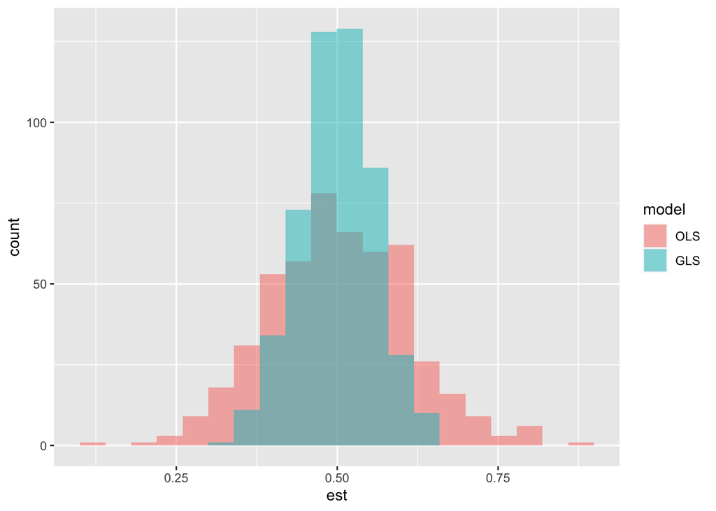

```r
## organize simulation results to make a plot
data_plot <- data.frame(est = c(coef_ols[,2], coef_exchmod[,2]),
                        model = c(rep("OLS", nsim), rep("GLS", nsim)))
data_plot$model <- factor(data_plot$model, levels = c("OLS", "GLS"))
ggplot(data_plot) +
  geom_histogram(aes(x = est, fill = model), alpha = 0.5, bins = 20, position = 'identity')
```

What do you observe?

Some ideas on why we see a reduced standard error using GLS. We are interested in estimating **changes** in the mean outcome over time, and we have correlated measurements over time within a subject. Assume $y_1$ is the first observation and $y_2$ is the second observation. The estimand $Var(y_2 - y_1) = Var(y_1) + Var(y_2) - 2Cov(y_1, y_2)$. In the OLS model we simply assume $Cov(y_1, y_2) = 0$.